# Table of Contents

## Comparing different maturity dates volume to understand volume behaviour of futures contracts

```python
contracts = symbols(['CLF18', 'CLG18', 'CLH18','CLJ18','CLK18'])
```

```python
contracts_volume =  history(contracts,'volume', frequency ='daily',start = '2017-06-01', end= '2018-04-30')
```

```python
contracts_price = history(contracts,'price', frequency ='daily',start = '2017-06-01', end= '2018-04-30')
```

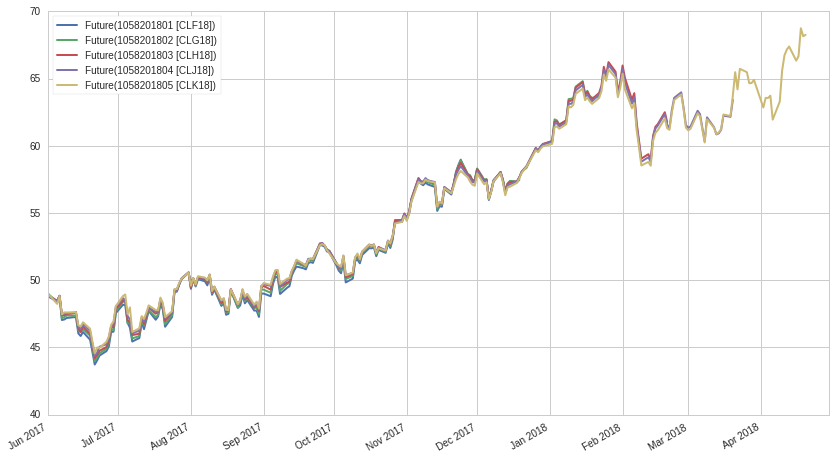

```python
contracts_price.plot(lw=2);
```

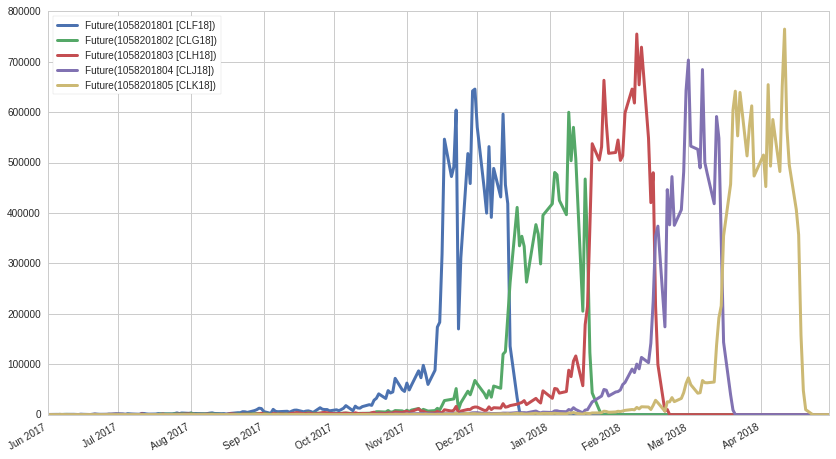

```python
contracts_volume.plot(lw=3);
```

[output not shown]

**`Delivery Month`**

Delivery month is key characteristic of a futures contract that designates when the contract expires and when the underlying asset must be delivered or settled. The exchange on the futures contract is traded will also establish a delivery location and a date within the delivery month when the delivery can take place. Not all futures contracts require physical delivery of a commodity, and many are settled in cash. The delivery month is also referred to as the contract month.

Delivery month is simply the month stipulated in the contract for cash settlement or physical delivery. Some commodities can be delivered in any month. Others are only delivered in certain months. If a futures trader is looking to offset or liquidate a position, the delivery months must match or the trader ends up long one month and short a different month rather than canceling out the position. Most futures positions are excited prior to the delivery month, so the contracts nearing delivery often see the most volume and set the current price of the underlying commodity.

## continuous futures contracts for continuous historical data

`Soure: Futures API Introduction quantopian`

Continuous futures are abstractions over the 'underlying' commodities/assets/indexes of futures. For example, if we wanted to trade crude oil, we could create a reference to `CL`, instead of a series of `CL` contracts. Continuous futures essentially maintain a reference to a 'current' contract deemed to be the active contract for the particular underlying.

```
        `Continuous futures help researchers visualize the continuous behavior of the futures`
```

```python
from quantopian.research.experimental import continuous_future
```

```python
print continuous_future.__doc__
```

```
    Create a specifier for a continuous contract.

    Parameters
    ----------
    root_symbol : str
        The root symbol for the continuous future.

    offset : int, optional
        The distance from the primary contract. Default is 0.

    roll : str, optional
        How rolls are determined. Options are 'volume' and 'calendar'. Default
        is 'volume'.

    adjustment : str
        Method for adjusting lookback prices between rolls. Options are
        'mul', 'add', and None. Default is 'mul'.

    Returns
    -------
    continuous_future : ContinuousFuture
        The continuous future specifier.
```

```python
# continuous future for crude oil volume approach
cl_adjusted = continuous_future('CL', offset=0, roll='volume', adjustment='mul')
cl_adjusted
```

```
ContinuousFuture(90999980378095616, root_symbol='CL', offset=0, roll_style='volume', adjustment='mul')
```

So there are 4 arguments that we need to consider.

- **`root_symbol`**: The root symbol of the underlying. For example, 'CL' for crude oil.
- **`offset`**: The distance from the primary contract. 0 = primary, 1 = secondary, etc. We'll get into this more later.
- **`roll`**: How to determine the 'current' contract of the continuous future. Current options are **`'volume'`** and **`'calendar'`**. The 'volume' approach chooses the current active contract based on trading volume. The 'calendar' approach chooses the current active contract based simply on the `auto_close_date`s of each contract.**
- **`adjustment`**: How to adjust historical prices from earlier contracts. Options are **`'mul'`**, **`'add'`**, or **`'None'`**.

## How to find the active contract of a continuous future contract

```python
cl_active_adjusted = history(cl_adjusted,
    fields=['contract', 'price', 'volume'],
    frequency='daily',
    start = '2017-06-01',
    end= '2018-04-30'
)
```

```python
cl_active_adjusted.tail(10)
```

|  | price | volume | contract |
| --- | --- | --- | --- |
| 2018-04-17 00:00:00+00:00 | 66.68 | 356830.0 | Future(1058201805 [CLK18]) |
| 2018-04-18 00:00:00+00:00 | 68.76 | 157560.0 | Future(1058201805 [CLK18]) |
| 2018-04-19 00:00:00+00:00 | 68.16 | 687663.0 | Future(1058201806 [CLM18]) |
| 2018-04-20 00:00:00+00:00 | 68.06 | 607989.0 | Future(1058201806 [CLM18]) |
| 2018-04-23 00:00:00+00:00 | 68.92 | 553945.0 | Future(1058201806 [CLM18]) |
| 2018-04-24 00:00:00+00:00 | 67.72 | 696814.0 | Future(1058201806 [CLM18]) |
| 2018-04-25 00:00:00+00:00 | 68.01 | 626134.0 | Future(1058201806 [CLM18]) |
| 2018-04-26 00:00:00+00:00 | 68.16 | 535933.0 | Future(1058201806 [CLM18]) |
| 2018-04-27 00:00:00+00:00 | 67.97 | 450185.0 | Future(1058201806 [CLM18]) |
| 2018-04-30 00:00:00+00:00 | 68.56 | 621203.0 | Future(1058201806 [CLM18]) |

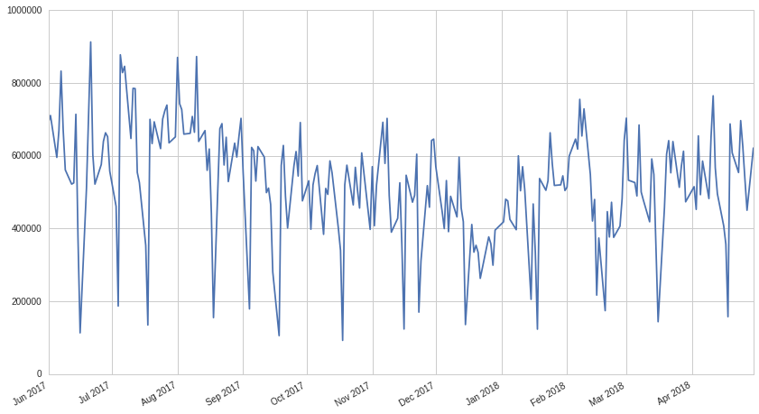

```python
cl_active_adjusted.volume.plot();
```

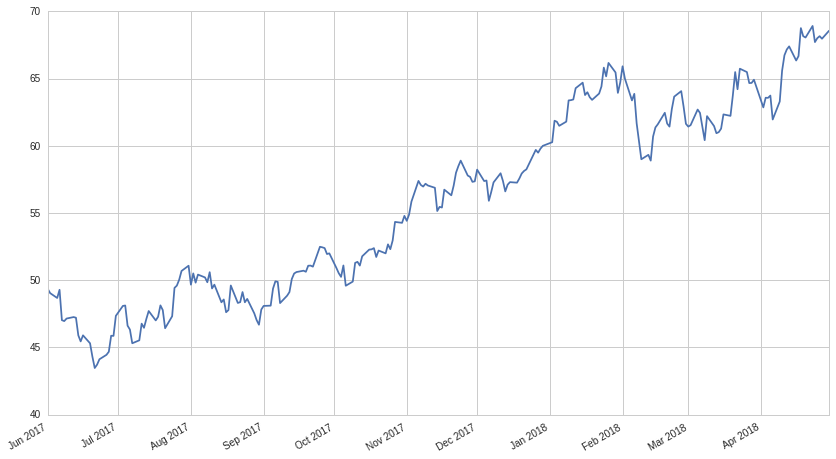

```python
cl_active_adjusted.price.plot();
```

## unadjusted continuous futures

```python
cl_unadjusted = continuous_future('CL', offset=0, roll='volume', adjustment=None)
cl_active_unadjusted = history(cl_unadjusted,
    fields=['contract', 'price', 'volume'],
    frequency='daily',
    start = '2017-06-01',
    end= '2018-04-30'
)

cl_active_unadjusted.price.plot();
```

[output not shown]

## lets see continuous future contract in action

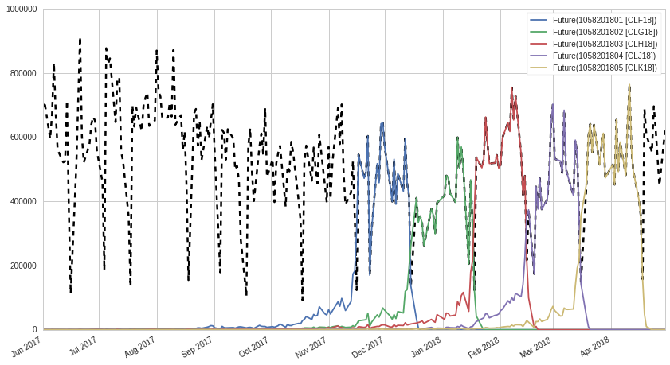

```python
ax = cl_active_unadjusted.volume.plot(lw=2.5, c = 'black', ls='--')
contracts_volume.plot(ax=ax, lw=1.8);
```

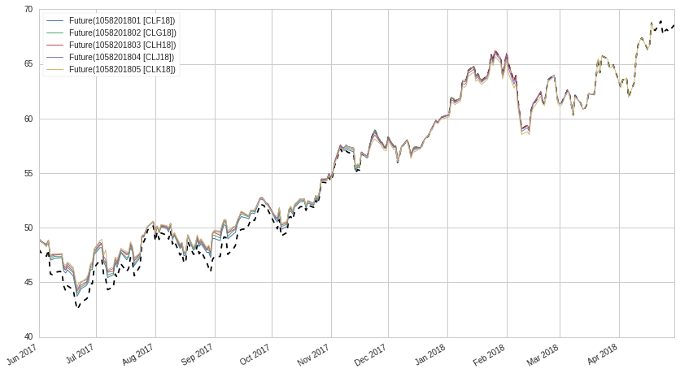

```python
ax = cl_active_unadjusted.price.plot(c='black', ls='--')
contracts_price.plot(lw=1, ax= ax)
```

## unadjusted continuous futures

```python
cl_unadjusted = continuous_future('CL', offset=0, roll='volume', adjustment=None)
cl_active_unadjusted = history(cl_unadjusted,
    fields=['contract', 'price', 'volume'],
    frequency='daily',
    start = '2017-06-01',
    end= '2018-04-30'
)

cl_active_unadjusted.price.plot()
```

[output not shown]

```python
cl_active_unadjusted.price.plot()
```

[output not shown]

## lets group each futures contract and plot price

```python
pivot_undjusted = cl_active_unadjusted.pivot(index= cl_active_unadjusted.index, columns='contract')
```

```python
pivot_undjusted.head()
```

| contract | price Future(1058201707 [CLN17]) | price Future(1058201708 [CLQ17]) | price Future(1058201709 [CLU17]) | price Future(1058201710 [CLV17]) | price Future(1058201711 [CLX17]) | price Future(1058201712 [CLZ17]) | price Future(1058201801 [CLF18]) | price Future(1058201802 [CLG18]) | price Future(1058201803 [CLH18]) | price Future(1058201804 [CLJ18]) | ... | volume Future(1058201709 [CLU17]) | volume Future(1058201710 [CLV17]) | volume Future(1058201711 [CLX17]) | volume Future(1058201712 [CLZ17]) | volume Future(1058201801 [CLF18]) | volume Future(1058201802 [CLG18]) | volume Future(1058201803 [CLH18]) | volume Future(1058201804 [CLJ18]) | volume Future(1058201805 [CLK18]) | volume Future(1058201806 [CLM18]) |
| --- | --- | --- | --- | --- | --- | --- | --- | --- | --- | --- | --- | --- | --- | --- | --- | --- | --- | --- | --- | --- | --- |
| 2017-06-01 00:00:00+00:00 | 48.04 | NaN | NaN | NaN | NaN | NaN | NaN | NaN | NaN | NaN | ... | NaN | NaN | NaN | NaN | NaN | NaN | NaN | NaN | NaN | NaN |
| 2017-06-02 00:00:00+00:00 | 47.74 | NaN | NaN | NaN | NaN | NaN | NaN | NaN | NaN | NaN | ... | NaN | NaN | NaN | NaN | NaN | NaN | NaN | NaN | NaN | NaN |
| 2017-06-05 00:00:00+00:00 | 47.39 | NaN | NaN | NaN | NaN | NaN | NaN | NaN | NaN | NaN | ... | NaN | NaN | NaN | NaN | NaN | NaN | NaN | NaN | NaN | NaN |
| 2017-06-06 00:00:00+00:00 | 47.98 | NaN | NaN | NaN | NaN | NaN | NaN | NaN | NaN | NaN | ... | NaN | NaN | NaN | NaN | NaN | NaN | NaN | NaN | NaN | NaN |
| 2017-06-07 00:00:00+00:00 | 45.78 | NaN | NaN | NaN | NaN | NaN | NaN | NaN | NaN | NaN | ... | NaN | NaN | NaN | NaN | NaN | NaN | NaN | NaN | NaN | NaN |

5 rows × 24 columns

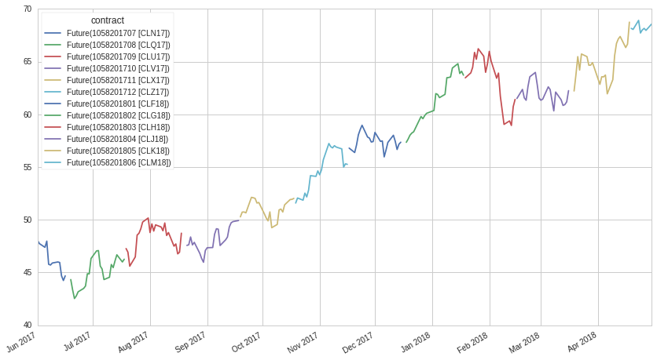

```python
pivot_undjusted.price.plot();
```

`Reference : Quantopian`